# Comparison of Natural vs. Restored Oysters

This analysis will focus on Ninigret Pond, because we have the presence of natural reefs, restored reefs, and aquaculture in order to make direct comparisons.

In Ninigret, we have 3 treatments for oysters:

Aquaculture

Natural (Foster Cove)

Restored (FHE)

# Compare Condition Indices:

## Number of replicates per treatment

```r
# Load necessary packages
library("plyr") #loads count()
# Read data into R
oyster_dat <- read.csv("oyster_data.csv")
# Subset only oysters collected in Ninigret/Foster Cove
ninigret_dat <- subset(oyster_dat, oyster_dat$Site == c("Ninigret FHE","Ninigret Aquaculture","Foster Cove"))
# Remove all oysters not measured for condition
CI_dat <- subset(ninigret_dat, ninigret_dat$Total_Mass_g != "")
CI_dat$Total_Mass_g <- as.numeric(CI_dat$Total_Mass_g )
CI_counts <- count(CI_dat$Site)
colnames(CI_counts) <- c("Treatment","Replicates")
CI_counts
```

| Treatment | Replicates |
| --- | --- |
| Foster Cove | 18 |
| Ninigret Aquaculture | 17 |
| Ninigret FHE | 20 |

```r
# Remove unnecessary columns
CI_dat <- CI_dat[,-c(7:10)]
```

The sample sizes are not equal, but they are very close.

## Calculate Condition Index

Condition Index is a common way to assess the effects of environmental conditions, such as salinity, temperature, tidal elevation, food quality, pollution, and presence of parasites, on oysters is by comparing condition index (CI) values among oysters exposed to differing conditions or located in various locations (e.g. Lawrence and Scott 1982, Rainer and Mann 1992, Rheault and Rice 1996).  
Formula for calculating CI:  
CI = (Tissue Dry Weight * 100)/(Shell Dry Weight)

```r
# Calculate CI for oysters
CI_dat$CI <- (CI_dat$Total_Dry_Tissue_g * 100)/(CI_dat$Total_Dry_Shell_g)
```

## Plot linear relationship of Dry Tissue / Dry Shell

```r
all_reg <- lm(CI_dat$Total_Dry_Tissue_g ~ CI_dat$Total_Dry_Shell_g)
print(summary(all_reg))
```

```
Call:
lm(formula = CI_dat$Total_Dry_Tissue_g ~ CI_dat$Total_Dry_Shell_g)

Residuals:
    Min      1Q  Median      3Q     Max
-1.9661 -0.5142 -0.3210 -0.0388  3.6624

Coefficients:
                         Estimate Std. Error t value Pr(>|t|)
(Intercept)              0.652701   0.226255   2.885  0.00565 **
CI_dat$Total_Dry_Shell_g 0.020032   0.007243   2.765  0.00781 **
---
Signif. codes:  0 ‘***’ 0.001 ‘**’ 0.01 ‘*’ 0.05 ‘.’ 0.1 ‘ ’ 1

Residual standard error: 1.077 on 53 degrees of freedom
Multiple R-squared:  0.1261,    Adjusted R-squared:  0.1096
F-statistic: 7.648 on 1 and 53 DF,  p-value: 0.007805
```

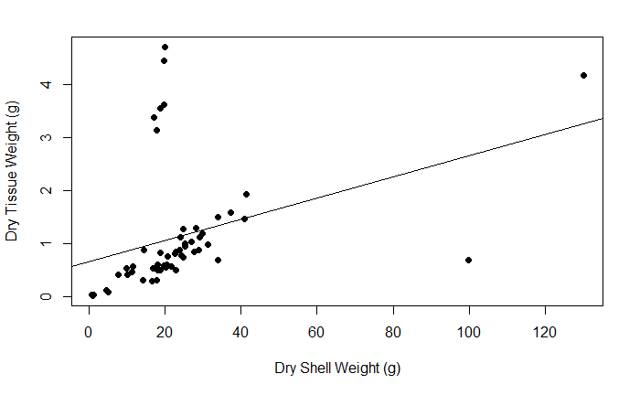

```r
plot(CI_dat$Total_Dry_Tissue_g ~ CI_dat$Total_Dry_Shell_g,
     xlab = "Dry Shell Weight (g)", ylab = "Dry Tissue Weight (g)",
     pch = 16)
abline(all_reg)
```

Adjusted R-squared: 0.1096

Some outliers are present.

## Plot linear relationship by Pond

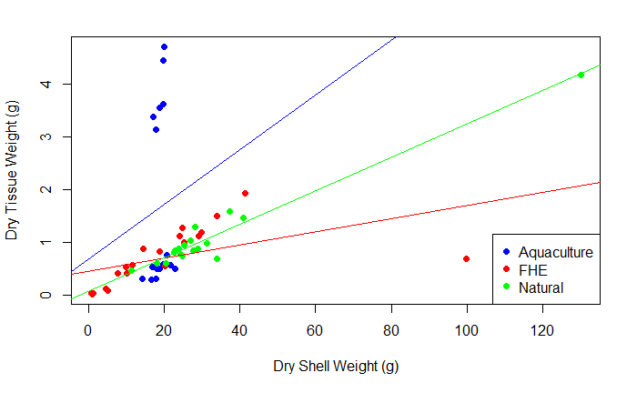

Better linear fits emerge

How do we explain outliers and relationship of Aquaculture?

First, let’s look at Aquacultured oysters

```r
aqua_dat <- subset(CI_dat, CI_dat$Culture == "Aquaculture")
print(aqua_dat[,c(8,10)])
```

|  | Wet_Tissue_g | Dry_Tissue_g |
| --- | --- | --- |
| 107 | 4.527 | 1.611 |
| 110 | 4.652 | 1.530 |
| 113 | 5.561 | 1.545 |
| 116 | 4.495 | 1.322 |
| 119 | 4.437 | 1.337 |
| 122 | 3.739 | 1.533 |
| 125 | 4.473 | 1.560 |
| 128 | 5.418 | 5.418 |
| 131 | 6.038 | 6.038 |
| 134 | 4.094 | 4.094 |

[output cut: 7 more lines]

We see that some oysters were not dried properly and wet tissue weight equals dry tissue weight. We will remove these oysters from the dataset.

```r
CI_dat <-CI_dat[!(CI_dat$Wet_Tissue_g == CI_dat$Dry_Tissue_g),]
```

6 oysters were removed from the dataset.

Next let’s look at the two oysters with extremely large dry shell weights.

```r
subset(CI_dat, CI_dat$Total_Dry_Shell_g > 90)
```

|  | Site | Culture | Date_Collected | Date_Processed | Quadrat_Num | Oyster_Num | Total_Mass_g | Wet_Tissue_g | Wet_Shell_g | Dry_Tissue_g | Dry_Shell_g | Sex | Shell_Length_mm | Total_Dry_Tissue_g | Total_Dry_Shell_g | Notes | CI |
| --- | --- | --- | --- | --- | --- | --- | --- | --- | --- | --- | --- | --- | --- | --- | --- | --- | --- |
| 334 | Ninigret FHE | FHE | 8/17/2016 | 8/26/2016 | 3 | 4 | 15 | 5.842 | 107.744 | 1.658 | 102.143 | N/A | 66 | 0.687 | 99.861 | on shell | 0.6879563 |
| 381 | Foster Cove | Natural | 8/31/2016 | 9/1/2016 | 3 | 1 | 62 | 22.621 | 138.314 | 5.496 | 132.151 | N/A | 97 | 4.186 | 130.022 |  | 3.2194552 |